# Part II - (Loan Data)

## by (Savita Devi)

> **Before you start**: I'm showing here how different fector like prosper rateing,BorrowerRate,Term affect on loan amount and borrowers.

## Investigation Overview

> For my presentation, I am focusing on features that would impact the loan amount. I have selected key plots which effectively convey the information. These plots show the distribution of key variables such as Loan Amount, Term, Prosper Rating, and Borrower Rate. I have attempted to illustrate the major predictors of Loan Amount using the Prosper Rating and Borrower Rate variables. My goal is to tell a story about these factors and how they influence the loan data.

## Dataset Overview

> This data set contains 84984 loans with 20 variables on each loan, including loan amount, borrower rate (or interest rate), current loan status, borrower income, and many others. 13 variable are quantitative in nature and 7 are of qualititative.

> This Data set further filtered on data after july 2009 because most columns are hold values after july 2009 like prosper rating,prosper score etc.

## (Visualization 1)

> In this visualization, I am showcasing the most preferred loan term and the most common borrower rating. The data reveals that 36 month loans are the most preferred, while 12 month loans are the least preferred. Borrowers with ratings of C and B are the most common, while those with the highest rating of AA borrow less frequently

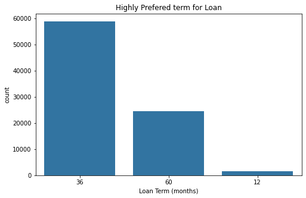

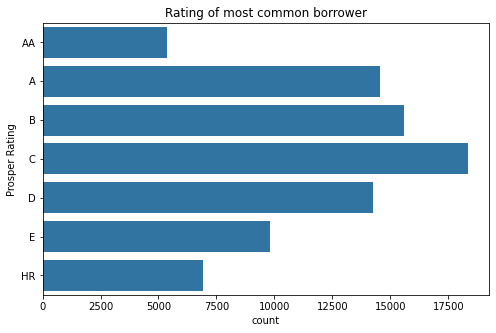

## (Visualization 2)

> The visualization shows that long term (60 month) and medium term (36 month) loans are popular among borrowers. Among these, 36 month loans are the most popular. 12 month loans are the least common among all borrowers. Rated A borrower in top position, more than 10000, in mid term loan.

> In the bivariate plot, it can be seen that borrowers with the lowest Prosper Rating (HR) have the highest Borrower Rate, which ranges from 0.3 to 0.35, with a few above 0.35. On the other hand, borrowers with the highest Prosper Rating (AA) have a Borrower Rate that ranges from 0.05 to 0.1 in most cases, but can reach up to 0.2, which is still significantly lower than the rates for the lower rated borrowers

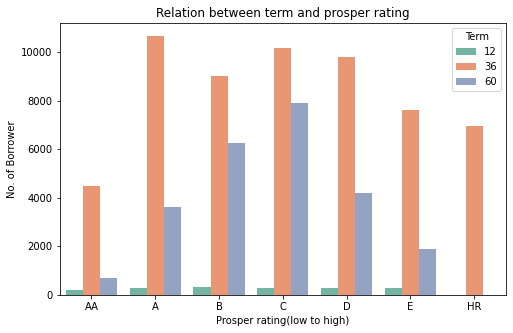

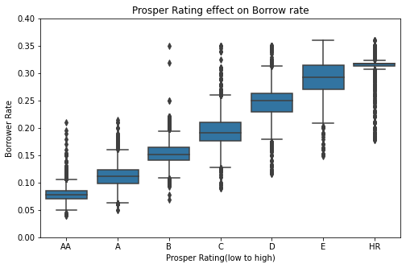

## (Visualization 3)

> As the Prosper Rating improves, the Loan Amount tends to increase. At the same time, the Borrower Rate decreases. There is an inverse relationship between the Borrower Rate and the Loan Amount when the Prosper Ratings are increased from HR to A or higher. It is clear that low Prosper Ratings have an adverse effect on both the Loan Amount and the Borrower Rate. Borrowers with Ratings of B and A are among the top borrowers with low Borrower Rates.

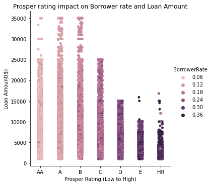